# NYC Council Data Science Test - Short Answer

Caffrey Lee

2020-01-18

# 1 Introduction

*The purpose of this document is for the NYC Council Data Science Interview. It is done by Caffrey Lee solely.*

This document only contains a brief description of the data, analysis, and the answers for the 4 questions. For detailed analysis and the code, please see the corresponding files that I submit it along with the file.

# 2 Data

The given data has *4798339 obs. of 18 variable*. And, it has some issues:

- *arrest_date is not in a date format;*
- *missing values;*
- *non-descriptive factors in categorical variables;*
- *too many categories for a single feature;*

After cleaning the data, the final data that I utilized for the analysis has *4789450 of observations with 20 columns (two additional date-related columns)* with a missing rate of *0%*. In short, the following analysis is based on the *99.81%* of the given data.

# 3 Data Preparation

## 3.1 Missing values:

The missing rows were filled up with NA for all columns, leading me to simply drop them. Also, the missing rates of the given data were not critical, **0.19%**.

## 3.2 Cleaning

- *AREREST_BORO* has 6 unique factors: B, K, M, Q, S, and " ". And, there were only 8 cases. So, I simply dropped them.
- *PERP_RACE* has 8 categories with UNKNOWN AND OTHERS. I prefer not to have unknown, especially when there is a category called “Other”. So, I put them together. (Note: one may think that this may not be a good idea, I agree)
- *AGE_GROUP* has 2000, 378, and other numbers that are not descriptive at all. Those non-descriptive numbers were recategorized into *UNKNOWN*
- *yr* and *yr_mon* were introduced for the analysis

# 4 Assumption

The analysis is based on the following assumptions:

- Assumptions:
  - I assume that the population does *not* fluctuate across time. (This is confirmed with the 2018 NYC population data from Statista: the total population is 8,398,748 when 8,242,624 is the total population that I used across the year; reference: https://www.statista.com/statistics/799563/resident-population-of-nyc-by-race/)
  - For simplicity, I *ignore* the traits of the neighbors such as the proportion of each ethnicity, social environment, economic status, and such.
  - I presume that every case is *independent*. This also excludes multiple crime, arrest, cases of a single person.
  - Consecutive observations are *equally spaced*
  - Apply a *discrete-time* index, yearly, (even though this may only hold approximately)

# 5 Analysis & Answer

## 5.1 Has the arrest rate been decreasing from 2015-2018? Describe the trend and defend any statistical tests used to support this conclusion.

**Note: Generally speaking, *arrest rate* is calculated as *Numb. Of Arrest (Types) / (Total) Population*. In the question, the definition of the arrest rate is a bit abstract. The rate could be based on the population*(uniformed)* or other variables such as race, age, borough, sex, arrest types, and such. Hence, I utilized the above-mentioned variables to calculate the arrest rate of each case by year as well as the total population to compute the overall arrest rate.**

The overall arrest rate throughout the time shows the **decreasing trend** (Feature 1,2); however, the arrest rate of race, gender, age group, borough, and the top 5 arrest types shows the different results (Feature 3,4): arrest rates of race, borough, and gender do not change much, while the top 5 arrest types(i.e. Felony Assault is listed as Top 5 in 2018 when Other Offenses Related is no longer in Top 5) and age group(i.e. in age group: 18-24 and 25-44, 5% decrease and increase for each group) display distinctive changes.

The result of the multivariate linear regression also states that the arrest rates are **decreasing** across the time, holding the above-mentioned variable fixed. Controlling for other variables, one year increase in a year would decrease the arrest rate by **-8.014e-07** on average.

## 5.2 What are the top 5 most frequent arrests as described in the column ‘pd_desc’ in 2018? Compare & describe the overall trends of these arrests across time.

**Note: Here, the question asked about the frequency, which I take it as the number of occurrences, instead of rate. That is, the following analysis is based on the *absolute number* rather than the rate, calculated by frequency/population**

The most frequent pd_desc types in 2018 are **Assult 3, Larceny Petit From Open Areas, Traffic, Assault 2&1, and Controlled Substance**. (please see Table 1 in the appendix)

## 5.3 If we think of arrests as a sample of total crime, is there more crime in precinct 19 (Upper East Side) than precinct 73 (Brownsville)? Describe the trend, variability and justify any statistical tests used to support this conclusion.

**Note: The question mentioned that the data, sample, could represent the total crime. That is, it is a representative sample that allows me to draw a conclusion of the population based on the analysis of the sample with confidence. Say that, number of arrests can represent the crime rates. With that in mind, the analysis is conducted. Also, I calculated the *monthly mean of arrests* of each precinct across the year, then take the *difference* between them. Here, I took the mean difference to alleviate the difference between the two districts as well as the difference across the time.**

Based on the *monthly mean of arrests*, one can say that Precinct 73 has a **greater average amount of crime** than precinct 19 across the time on average(Feature 7). Yet, to answer this question, one should be careful since the analysis disregard the demographic difference between the two communities. To confirm, I ran a linear regression (Feature 8).

And, the P-val of the precinct 73, **location**, does **not** have a statistical impact on the mean of crimes, controlling the year fixed. In contrast, the year has a statistical impact on the monthly mean number of arrests.

Regarding the trend, one could say that it is **moving from increasing to decreasing trend from 2011 with seasonality**. This happens mostly because the crime rates in precinct 73 are decreasing. For instance, after reaching the peak rate, 43.87%, in 2011-07, it gradually decreases. And, the rate remains around 13% since 2018-08 (Feature 9).

*Further research on the characteristics of each neighborhood such as ethnicity, environment, economic status, and such could help one to have a better understanding of the crime rates between the two communities.*

## 5.4 What model would you build to predict crime to better allocate NYPD resources? What challenges do you foresee? What variables would be included? How would you evaluate the model? Discuss in no more than 150 words.

Forecasting, in general, is difficult, especially when the outcome is expected to be influenced by unexpected variables. Hence, to select a model, I generated various models. And, based on the AIC, RMSE, ME, and MPE of the multiple models, I would utilize the *ARIMA(0,1,1)(0,1,1)[12]* model to forecast crime.

The analysis is based on the arrest rate based on *uniformed total population* across the year. As the above analysis shows, this tends to ignore the difference among the districts, race, age group, borough, crime types and such.

Incorporating the variables that could *explain the characteristics of each district* - race, age group, borough, and crime types - would be helpful. Still, this is *vulnerable to bias*.

As an evaluation, I would pay attention to *RMSE, ME, and MPE more* because large errors are undesirable in terms of forecasting, and ME and MPE allow for the bias check.

# 6 Appendix

## 6.1 Question 1.

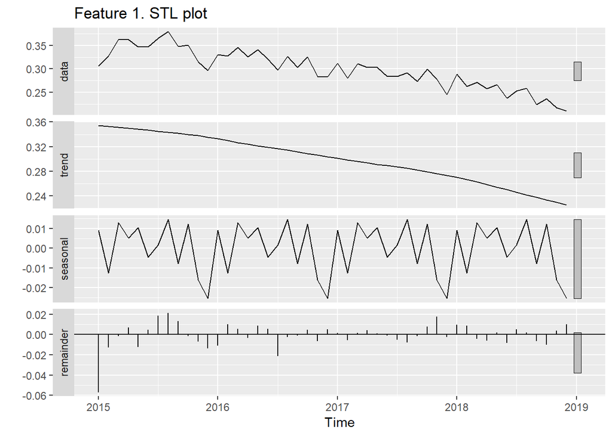

```r
total.pop = unique(pop$total)
# making sure that dates are ascending order
setorderv(x = dat, cols = 'arrest_date', order = 1)

arrest.dat = dat[, .N, by = c('yr_mon')]
arrest.dat = arrest.dat[, .(Rate = (N/total.pop)*100), by = yr_mon]

# creating the ts dat
ts.dat = ts(data = arrest.dat[,-1], start = c(2006,1), end = c(2018,12), frequency = 12)

# parsing only 2015 to 2018
ts.dat.window = window(ts.dat, 2015, c(2018,12))

#time(ts.dat.window)
#cycle(ts.dat.window)
#cor(ts.dat.window, lag(ts.dat.window), use = 'complete.obs')

#autoplot(ts.dat.window, facet = T)+ ylab('Overall Arrest Rate')

# STL (Seasonality and Trend Decomposition using Loess)
autoplot(stl(ts.dat.window[,1], s.window = 'periodic', robust = T), main = "Feature 1. STL plot")
```

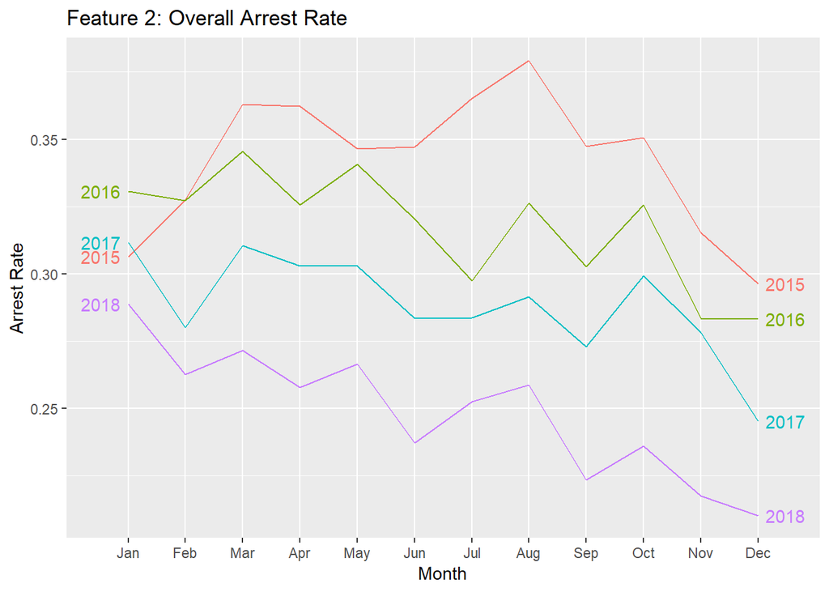

```r
#ggAcf(ts.dat.window, lag.max = 12*4)
#pacf(ts.dat.window)

# Chekcing for the seaonality
ggseasonplot(ts.dat.window, year.labels = TRUE, year.labels.left = TRUE) +
  ylab("Arrest Rate") +
  xlab("Month") +
  ggtitle("Feature 2: Overall Arrest Rate") # Weak Seaonality
```

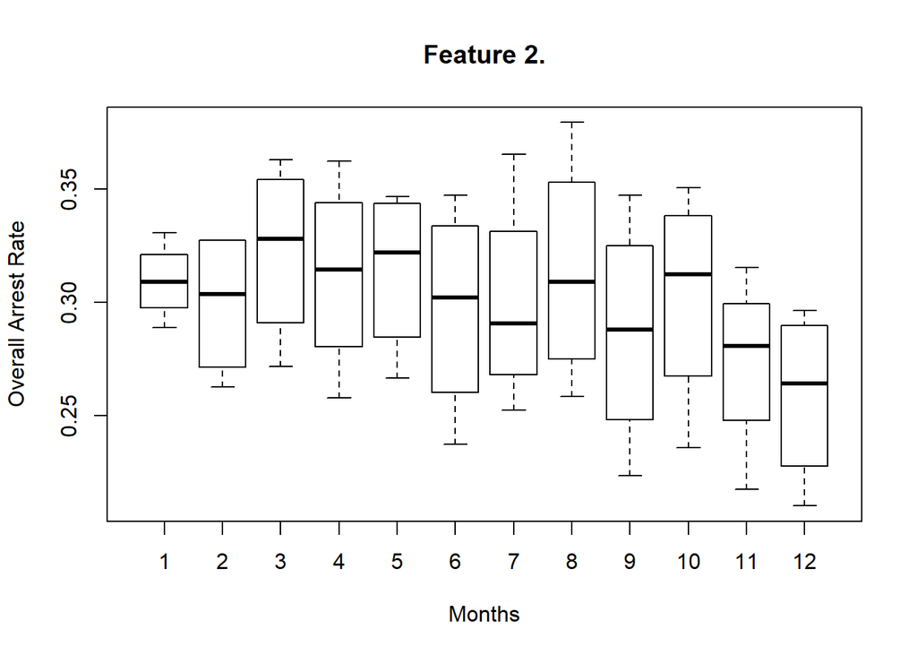

```r
# Variation by the month
#ggsubseriesplot(ts.dat.window) +
#  ylab("Arrest Rate") +
#  xlab("Month") +
#  ggtitle("Sub Seasonal Plot: Overall Arrest Rate")


boxplot(ts.dat.window~cycle(ts.dat.window), xlab = 'Months', ylab = 'Overall Arrest Rate', main = "Feature 2.")
```

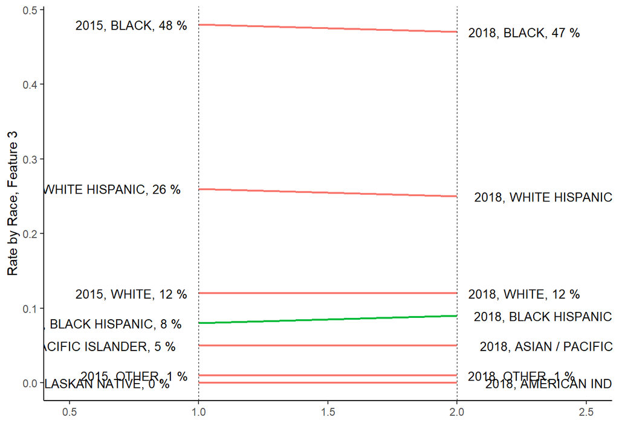

```r
# Race
rate.by.race = dat[yr >= 2015, .N, by = c('yr','perp_race')]
rate.by.race[, rate := round((N / total.pop)*100, digits = 2), by = yr]
rate.by.race[, perc := round(rate / sum(rate), digits = 2), by = yr]
setorderv(rate.by.race, cols = c('yr', 'perp_race'), order = c(-1,1))
setnames(x = rate.by.race, old = 'perp_race', new = 'target')

create.slop.chart(dat = rate.by.race, title = 'Race, Feature 3')
```

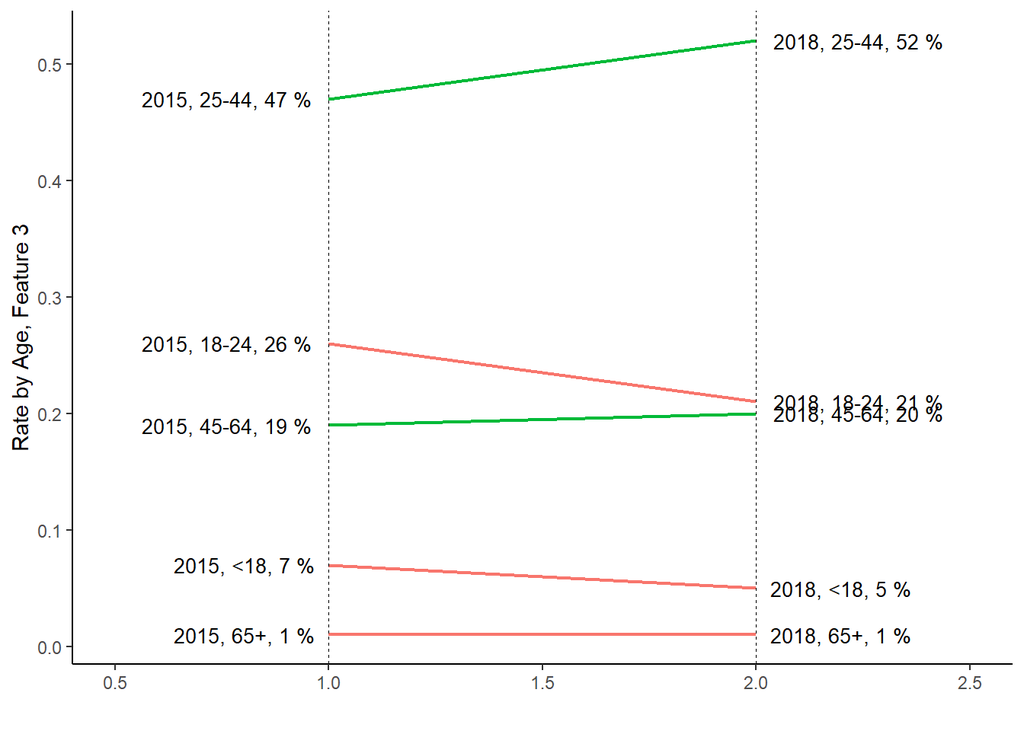

```r
# age
rate.by.age = dat[yr >= 2015, .N, by = c('yr','age_group')]
rate.by.age[, rate := round((N / total.pop)*100, digits = 2), by = yr]
rate.by.age[, perc := round(rate / sum(rate), digits = 2), by = yr]
setorderv(rate.by.age, cols = c('yr', 'age_group'), order = c(-1,1))
setnames(x = rate.by.age, old = 'age_group', new = 'target')

create.slop.chart(rate.by.age, 'Age, Feature 3')
```

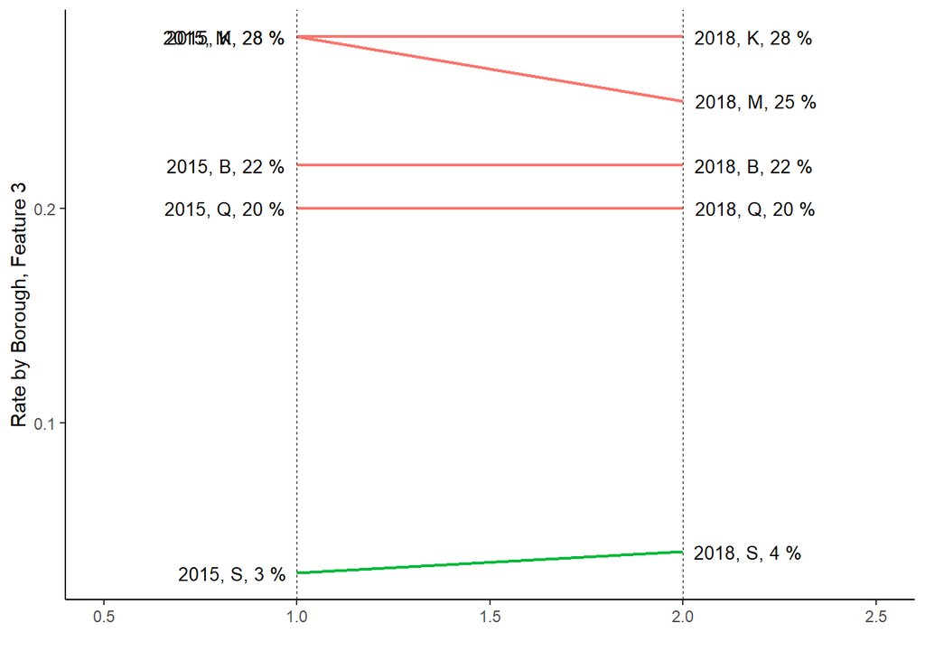

```r
# borough
rate.by.borough = dat[yr >= 2015, .N, by = c('yr','arrest_boro')]
rate.by.borough[, rate := round((N / total.pop)*100, digits = 2), by = yr]
rate.by.borough[, perc := round(rate / sum(rate), digits = 2), by = yr]
setorderv(rate.by.borough, cols = c('yr', 'arrest_boro'), order = c(-1,1))
setnames(x = rate.by.borough, old = 'arrest_boro', new = 'target')

create.slop.chart(dat = rate.by.borough, 'Borough, Feature 3')
```

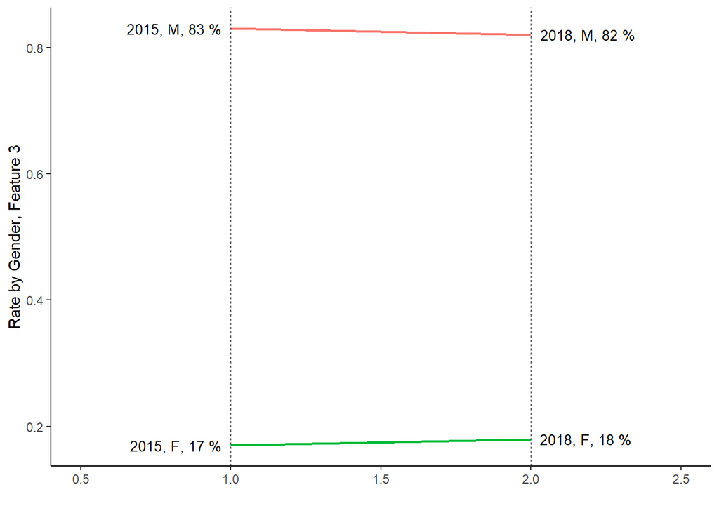

```r
# sex
rate.by.sex = dat[yr >= 2015, .N, by = c('yr','perp_sex')]
rate.by.sex[, rate := round((N / total.pop)*100, digits = 2), by = yr]
rate.by.sex[, perc := round(rate / sum(rate), digits = 2), by = yr]
setorderv(rate.by.sex, cols = c('yr', 'perp_sex'), order = c(-1,1))
setnames(x = rate.by.sex, old = 'perp_sex', new = 'target')

create.slop.chart(dat = rate.by.sex, 'Gender, Feature 3')
```

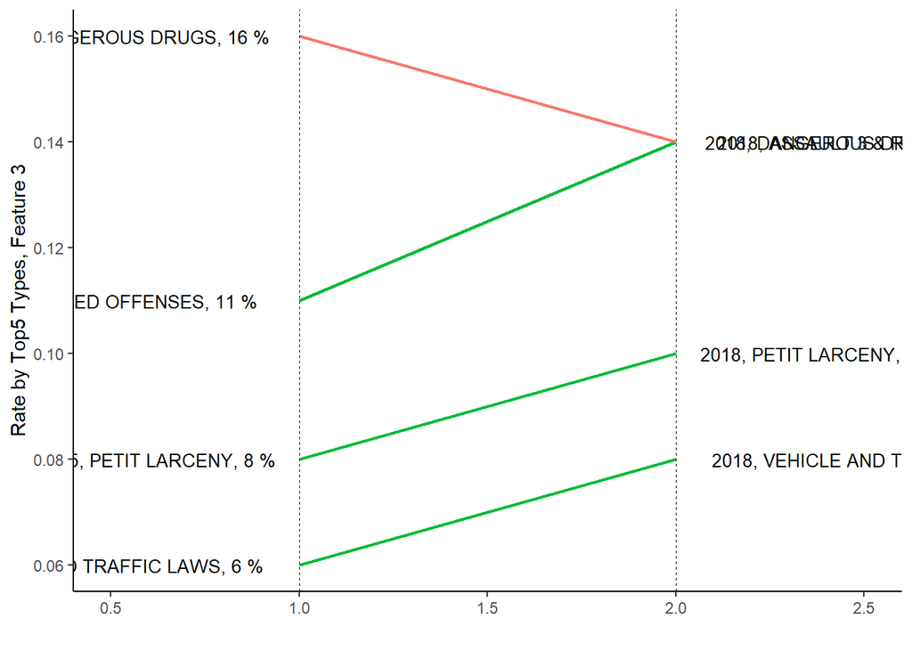

```r
# offense description
rate.by.ofns_desc = dat[yr >= 2015, .N, by = c('yr','ofns_desc')]
rate.by.ofns_desc[, rate := round((N / total.pop)*100, digits = 2), by = yr]
rate.by.ofns_desc[, perc := round(rate / sum(rate), digits = 2), by = yr]
setorderv(rate.by.ofns_desc, cols = c('yr', 'perc'), order = c(-1,-1))
setnames(x = rate.by.ofns_desc, old = 'ofns_desc', new = 'target')

# take the top 5
rate.by.ofns_desc.top5 = rate.by.ofns_desc[, .SD[1:5] , by = yr]


create.slop.chart(dat = rate.by.ofns_desc.top5, 'Top5 Types, Feature 3')
```

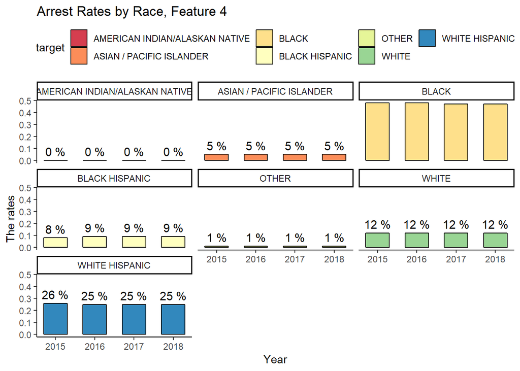

```r
# by race
create.histogram(dat = rate.by.race, title = 'Race, Feature 4')
```

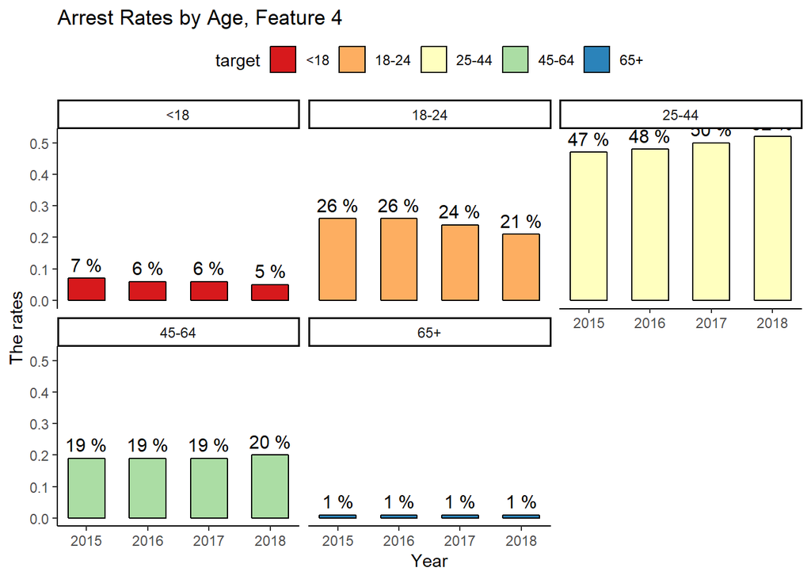

```r
# by age
create.histogram(dat = rate.by.age, title = 'Age, Feature 4')
```

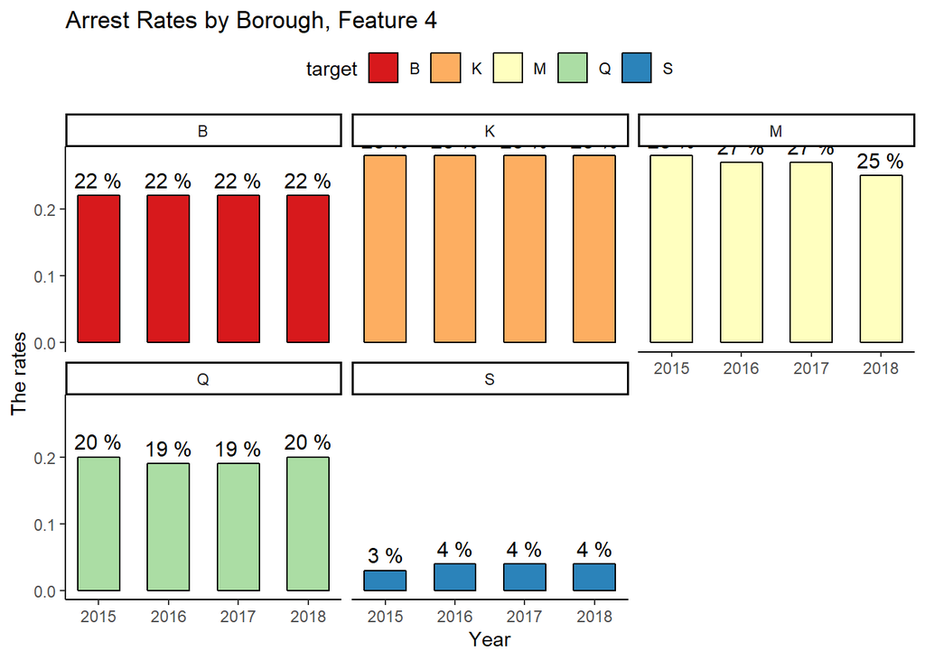

```r
# by borough
create.histogram(dat = rate.by.borough, title = 'Borough, Feature 4')
```

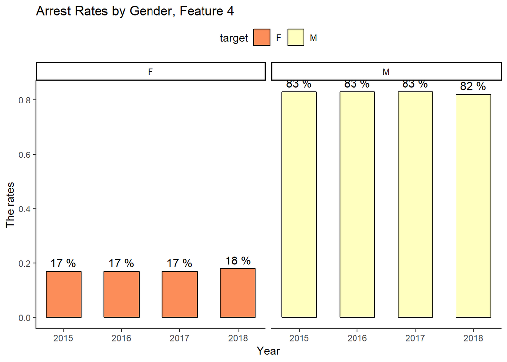

```r
# by sex
create.histogram(dat = rate.by.sex, title = 'Gender, Feature 4')
```

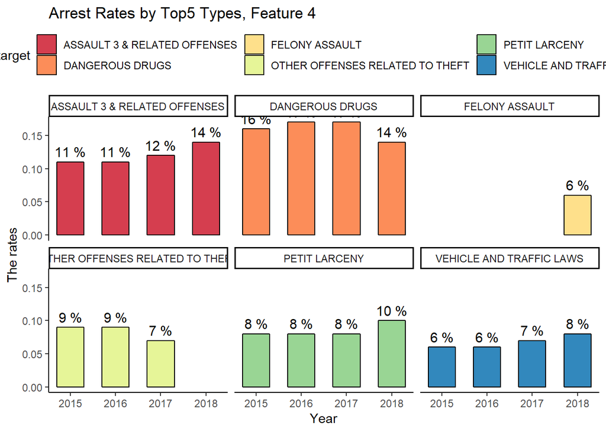

```r
# by ofns_desc
create.histogram(dat = rate.by.ofns_desc.top5, title = 'Top5 Types, Feature 4')
```

```r
rm(rate.by.age)
rm(rate.by.borough)
rm(rate.by.ofns_desc)
rm(rate.by.race)
rm(rate.by.sex)


q1.dat = dat[yr >=2015 & ofns_desc %in% unique(rate.by.ofns_desc.top5$target), .N, by = c('arrest_date', 'age_group', 'perp_race', 'perp_sex', 'arrest_boro', 'ofns_desc', 'yr', 'yr_mon')]

rm(rate.by.ofns_desc.top5)

q1.dat[, Rate:= (N/total.pop)*100, by = yr]

formula = create.formula(outcome.name = 'Rate', input.names = c('age_group', 'perp_race', 'perp_sex', 'arrest_boro', 'ofns_desc', 'yr'), dat = q1.dat, max.input.categories = 7, reduce = T)

lm = lm(formula = formula, data = q1.dat)
summary(lm)
```

```
Call:
lm(formula = formula, data = q1.dat)

Residuals:
       Min         1Q     Median         3Q        Max
-3.396e-05 -1.013e-05 -3.060e-06  5.320e-06  4.551e-04

Coefficients:
                                           Estimate Std. Error t value Pr(>|t|)
(Intercept)                               1.614e-03  5.269e-05  30.627  < 2e-16
age_group18-24                            6.298e-06  1.196e-07  52.675  < 2e-16
age_group25-44                            1.304e-05  1.151e-07 113.256  < 2e-16
age_group45-64                            5.430e-06  1.217e-07  44.629  < 2e-16
age_group65+                             -2.495e-06  2.352e-07 -10.608  < 2e-16
perp_raceASIAN / PACIFIC ISLANDER         3.634e-06  4.391e-07   8.276  < 2e-16
perp_raceBLACK                            1.682e-05  4.274e-07  39.351  < 2e-16
perp_raceBLACK HISPANIC                   3.294e-06  4.334e-07   7.602 2.93e-14
perp_raceOTHER                           -1.282e-06  4.879e-07  -2.627  0.00861
perp_raceWHITE                            5.236e-06  4.310e-07  12.148  < 2e-16
perp_raceWHITE HISPANIC                   1.013e-05  4.284e-07  23.655  < 2e-16
perp_sexM                                 9.877e-06  6.577e-08 150.171  < 2e-16
arrest_boroK                              4.582e-07  8.421e-08   5.441 5.29e-08
arrest_boroM                              8.951e-07  8.280e-08  10.810  < 2e-16
arrest_boroQ                             -3.415e-06  8.913e-08 -38.316  < 2e-16
arrest_boroS                             -8.582e-06  1.377e-07 -62.319  < 2e-16
ofns_descDANGEROUS DRUGS                  6.634e-06  8.661e-08  76.598  < 2e-16
ofns_descFELONY ASSAULT                  -5.999e-06  1.033e-07 -58.068  < 2e-16
ofns_descOTHER OFFENSES RELATED TO THEFT -1.197e-06  1.038e-07 -11.537  < 2e-16
ofns_descPETIT LARCENY                   -2.500e-06  9.213e-08 -27.132  < 2e-16
ofns_descVEHICLE AND TRAFFIC LAWS        -4.390e-06  9.996e-08 -43.916  < 2e-16
yr                                       -8.014e-07  2.613e-08 -30.671  < 2e-16

(Intercept)                              ***
age_group18-24                           ***
age_group25-44                           ***
age_group45-64                           ***
age_group65+                             ***
perp_raceASIAN / PACIFIC ISLANDER        ***
perp_raceBLACK                           ***
perp_raceBLACK HISPANIC                  ***
perp_raceOTHER                           **
perp_raceWHITE                           ***
perp_raceWHITE HISPANIC                  ***
perp_sexM                                ***
arrest_boroK                             ***
arrest_boroM                             ***
arrest_boroQ                             ***
arrest_boroS                             ***
ofns_descDANGEROUS DRUGS                 ***
ofns_descFELONY ASSAULT                  ***
ofns_descOTHER OFFENSES RELATED TO THEFT ***
ofns_descPETIT LARCENY                   ***
ofns_descVEHICLE AND TRAFFIC LAWS        ***
yr                                       ***
---
Signif. codes:  0 '***' 0.001 '**' 0.01 '*' 0.05 '.' 0.1 ' ' 1

Residual standard error: 1.696e-05 on 350946 degrees of freedom
Multiple R-squared:  0.2215,    Adjusted R-squared:  0.2214
F-statistic:  4754 on 21 and 350946 DF,  p-value: < 2.2e-16
```

```r
rm(q1.dat)
```

## 6.2 Question 2.

```r
pd_desc.num = length(unique(dat$pd_desc))
pd_desc.uniq = unique(dat$pd_desc)

tab = dat[yr == 2018, .N, by = pd_desc][order(-N)]
tab[, perc := round(N / sum(N) *100, digits = 2)]

datatable(tab[1:5], rownames = F, caption = 'Table 1.')
```

| pd_desc | N | perc |
| --- | --- | --- |
| ASSAULT 3 | 26611 | 10.82 |
| LARCENY,PETIT FROM OPEN AREAS,UNCLASSIFIED | 23405 | 9.52 |
| TRAFFIC,UNCLASSIFIED MISDEMEAN | 14856 | 6.04 |
| ASSAULT 2,1,UNCLASSIFIED | 11763 | 4.78 |
| CONTROLLED SUBSTANCE, POSSESSION 7 | 9982 | 4.06 |

```r
top.5.pd_desc = tab[, pd_desc][1:5]

# parsing the top 5 from the overall data
comparison.tab = dat[pd_desc %in% top.5.pd_desc, .N, by = c('yr','pd_desc')]

comparison.tab[, perc := round(N / sum(N), digits = 2), by = yr]
setorderv(comparison.tab, cols = c('yr', 'perc'), order = c(-1,-1))
comparison.tab[, rank:= 1:.N, by = yr]
comparison.tab[, diff:= rank - shift(rank), by = pd_desc]
datatable(comparison.tab, rownames = F, caption = 'Table 1-1.')
```

| yr | pd_desc | N | perc | rank | diff |
| --- | --- | --- | --- | --- | --- |
| 2018 | ASSAULT 3 | 26611 | 0.31 | 1 |  |
| 2018 | LARCENY,PETIT FROM OPEN AREAS,UNCLASSIFIED | 23405 | 0.27 | 2 |  |
| 2018 | TRAFFIC,UNCLASSIFIED MISDEMEAN | 14856 | 0.17 | 3 |  |
| 2018 | ASSAULT 2,1,UNCLASSIFIED | 11763 | 0.14 | 4 |  |
| 2018 | CONTROLLED SUBSTANCE, POSSESSION 7 | 9982 | 0.12 | 5 |  |
| 2017 | ASSAULT 3 | 26281 | 0.29 | 1 | 0 |
| 2017 | LARCENY,PETIT FROM OPEN AREAS,UNCLASSIFIED | 23020 | 0.26 | 2 | 0 |
| 2017 | TRAFFIC,UNCLASSIFIED MISDEMEAN | 16298 | 0.18 | 3 | 0 |
| 2017 | CONTROLLED SUBSTANCE, POSSESSION 7 | 12341 | 0.14 | 4 | -1 |
| 2017 | ASSAULT 2,1,UNCLASSIFIED | 11911 | 0.13 | 5 | 1 |

[output cut: 55 more lines]

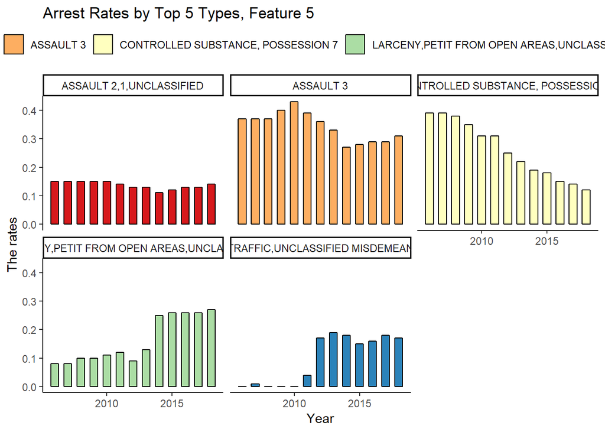

```r
setnames(x = comparison.tab, old = 'pd_desc', new = 'target')

create.histogram(dat = comparison.tab, title = 'Top 5 Types, Feature 5', show.labels = F)
```

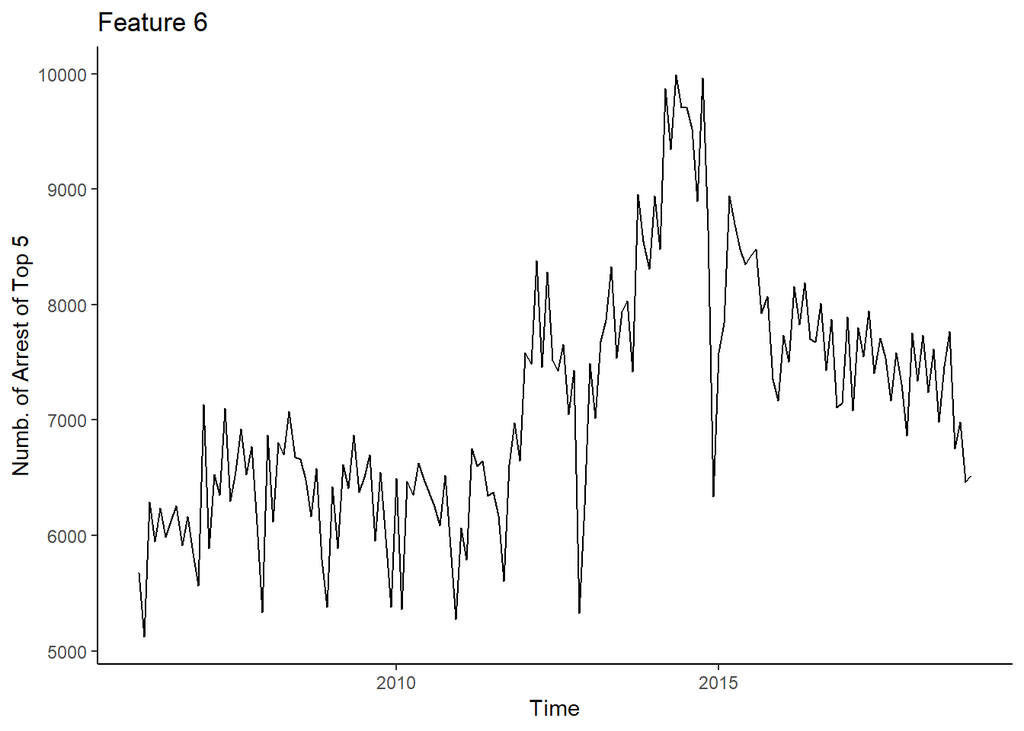

```r
## overal time series
top.5.dat = dat[pd_desc %in% top.5.pd_desc, .N, by = c( 'yr_mon')]
#top.5.dat = top.5.dat[, mean:= mean(N), by = c('yr_mon')]

top.ts = ts(data = top.5.dat[,-1], start = c(2006,1), end = c(2018,12), frequency = 12)

autoplot(top.ts, facet = T, main = 'Feature 6')+ ylab('Numb. of Arrest of Top 5')
```

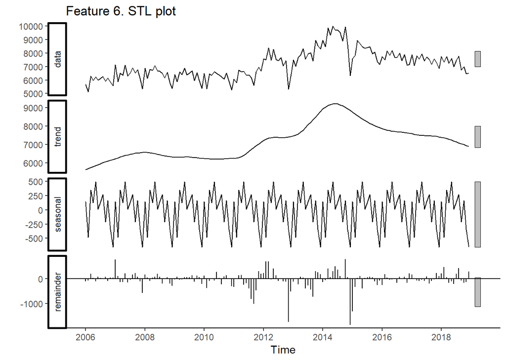

```r
#ggAcf(x = top.ts, lag.max = 12*12)
#pacf(top.ts)
# it is highly auto-correlated with the adjecent year and the year before with high seasonality

# STL (Seasonality and Trend Decomposition using Loess)
autoplot(stl(top.ts[,1], s.window = 'periodic', robust = T), main = 'Feature 6. STL plot')
```

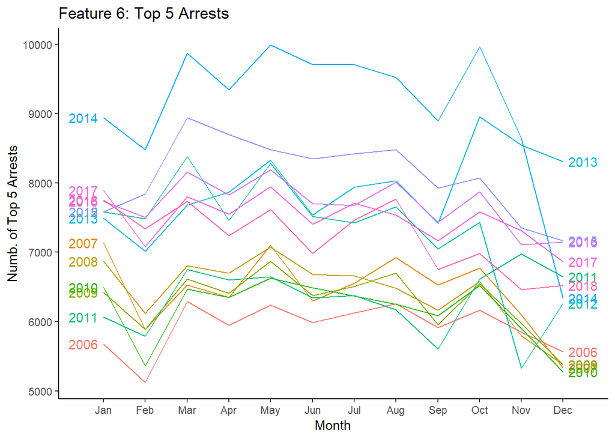

```r
# Chekcing for the seaonality
ggseasonplot(top.ts, year.labels = TRUE, year.labels.left = TRUE) +
  ylab("Numb. of Top 5 Arrests") +
  xlab("Month") +
  ggtitle("Feature 6: Top 5 Arrests")
```

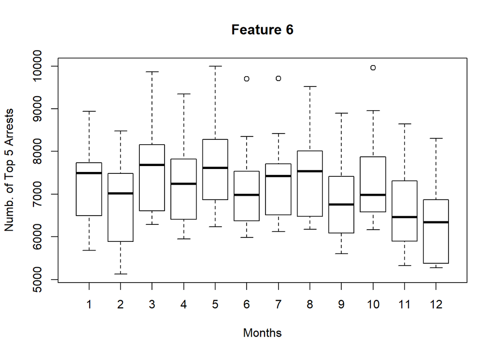

```r
# Variation by the month
#ggsubseriesplot(top.ts) +
#  ylab("Numb. of Top 5 Arrests") +
#  xlab("Month") +
#  ggtitle("Sub Seasonal Plot: Top 5 Arrests")

boxplot(top.ts~cycle(top.ts), xlab = 'Months', ylab = 'Numb. of Top 5 Arrests', main= 'Feature 6')
```

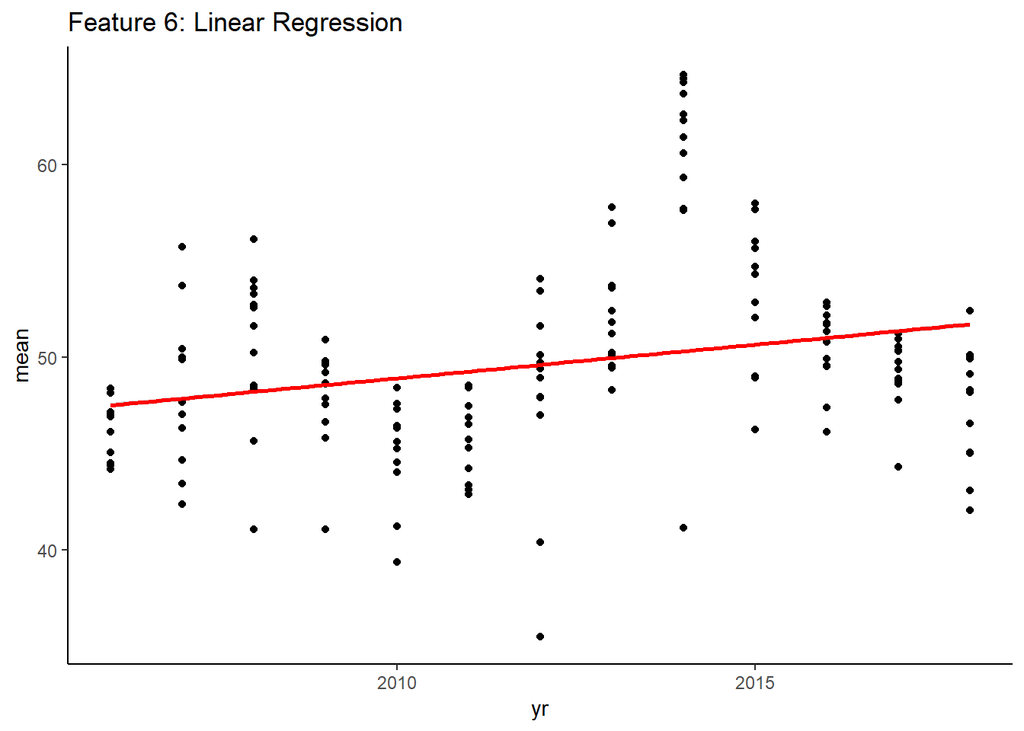

```r
q2.dat = dat[pd_desc %in% top.5.pd_desc, .N, by = c('yr','pd_desc', 'arrest_date', 'yr_mon')]

q2.dat[, mean:= mean(N), by = yr_mon]

#formula2 = create.formula(outcome.name = 'mean', input.names = c('yr', 'pd_desc'), dat = q2.dat)

#lm2 = lm(formula = formula2, data = q2.dat)
#summary(lm2)

ggplot(q2.dat, aes(x = yr, y = mean)) +
  geom_point() +
  stat_smooth(method = "lm", col = "red") +
  ggtitle("Feature 6: Linear Regression")
```

```r
rm(q2.dat)
```

## 6.3 Question 3.

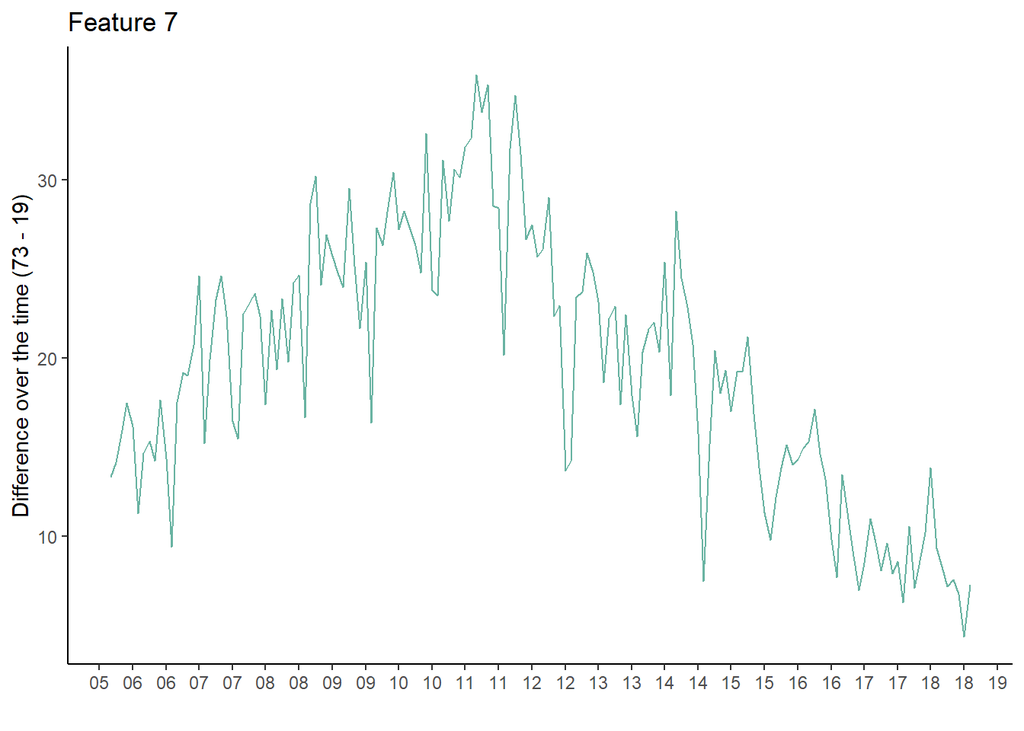

```r
# parsing 19
tab.19 = dat[arrest_precinct == 19, .N, by = c('arrest_date','arrest_precinct', 'yr_mon')]
# compute the arrest rate by mean of month
tab.19 = tab.19[, mean(N), by= yr_mon]
setnames(x = tab.19, old = 'V1', new = '19')

# parsing 73
tab.73 = dat[arrest_precinct == 73, .N, by = c('arrest_date','arrest_precinct','yr_mon')]
# compute the arrest rate by mean of month
tab.73 = tab.73[, mean(N), by= yr_mon]
setnames(x = tab.73, old = 'V1', new = '73')

tab.19.73 = merge(tab.19, tab.73, by = 'yr_mon')

#basic.stat(tab.19.73$`19`)
#basic.stat(tab.19.73$`73`)
#cor(tab.19.73$`19`, tab.19.73$`73`)

tab.19.73[, mean_diff := `73` - `19`, by = yr_mon]

ggplot(tab.19.73, aes(x=as.Date(paste0(yr_mon,"-01")), y=mean_diff)) +
  geom_line(color = '#69b3a2')+
  xlab("") +
  ylab("Difference over the time (73 - 19)")+
  ggtitle("Feature 7") +
  scale_x_date(date_breaks = "6 month", date_labels = "%y")
```

```r
q3.dat = dat[arrest_precinct == 19 | arrest_precinct == 73, .N, by = c('yr', 'arrest_date', 'yr_mon', 'arrest_precinct')]

q3.dat[, mean := mean(N), by = yr_mon]
q3.dat$arrest_precinct = as.factor(q3.dat$arrest_precinct)

formula3 = create.formula(outcome.name = 'mean', input.names = c('yr', 'arrest_precinct'), dat = q3.dat)

lm3 = lm(formula = formula3, data = q3.dat)
summary(lm3)
```

```
Call:
lm(formula = formula3, data = q3.dat)

Residuals:
    Min      1Q  Median      3Q     Max
-7.6214 -2.8034 -0.1228  2.6316  7.1568

Coefficients:
                    Estimate Std. Error t value Pr(>|t|)
(Intercept)        1.458e+03  1.884e+01  77.424   <2e-16 ***
yr                -7.156e-01  9.362e-03 -76.443   <2e-16 ***
arrest_precinct73 -5.429e-03  7.006e-02  -0.077    0.938
---
Signif. codes:  0 '***' 0.001 '**' 0.01 '*' 0.05 '.' 0.1 ' ' 1

Residual standard error: 3.409 on 9469 degrees of freedom
Multiple R-squared:  0.3816,    Adjusted R-squared:  0.3815
F-statistic:  2922 on 2 and 9469 DF,  p-value: < 2.2e-16
```

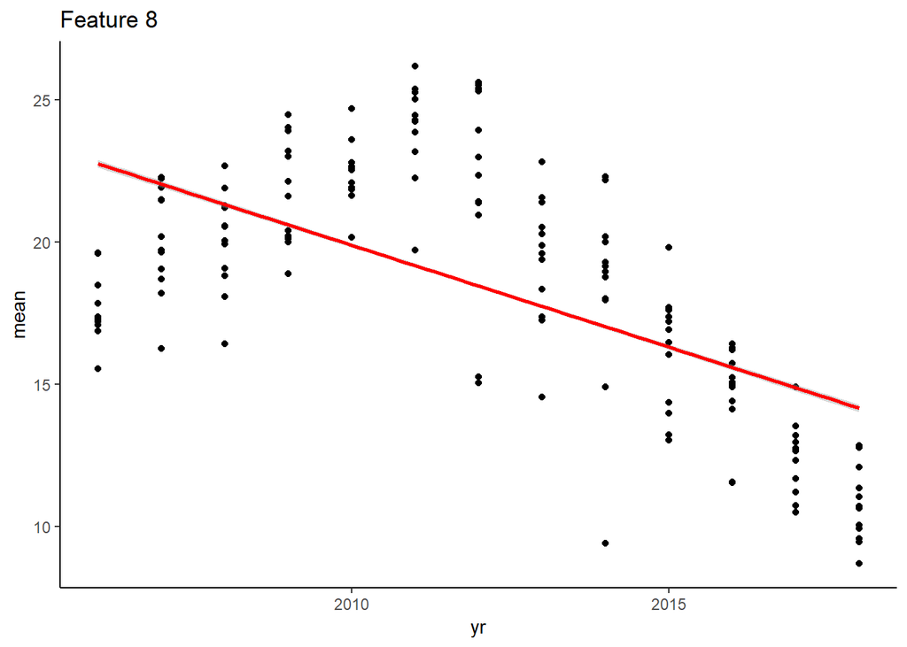

```r
ggplot(q3.dat, aes(x = yr, y = mean)) +
  geom_point() +
  ggtitle("Feature 8") +
  stat_smooth(method = "lm", col = "red")
```

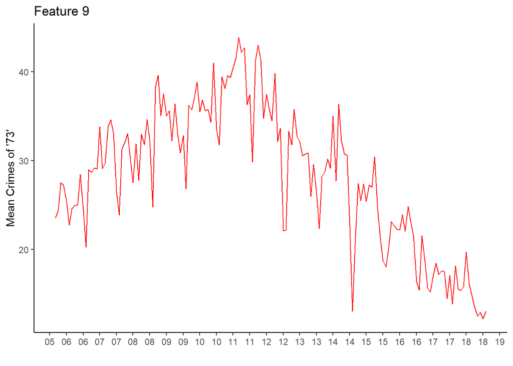

```r
rm(q3.dat)

ggplot(tab.19.73, aes(x=as.Date(paste0(yr_mon,"-01")), y=`73`)) +
  geom_line(color = 'red')+
  xlab("") +
  ylab("Mean Crimes of '73'")+
  ggtitle("Feature 9")+
  scale_x_date(date_breaks = "6 month", date_labels = "%y")
```

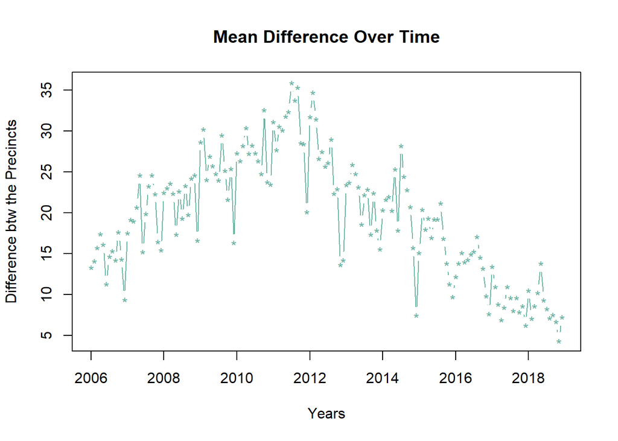

```r
final.tab = tab.19.73[, c(1,4)]

ts.dat = ts(data = final.tab[,-1], start = c(2006,1), end = c(2018,12), frequency = 12)

plot.ts(ts.dat, type= "b", main = "Mean Difference Over Time", xlab = "Years", ylab = "Difference btw the Precincts", col = '#69b3a2', pch = "*")
```

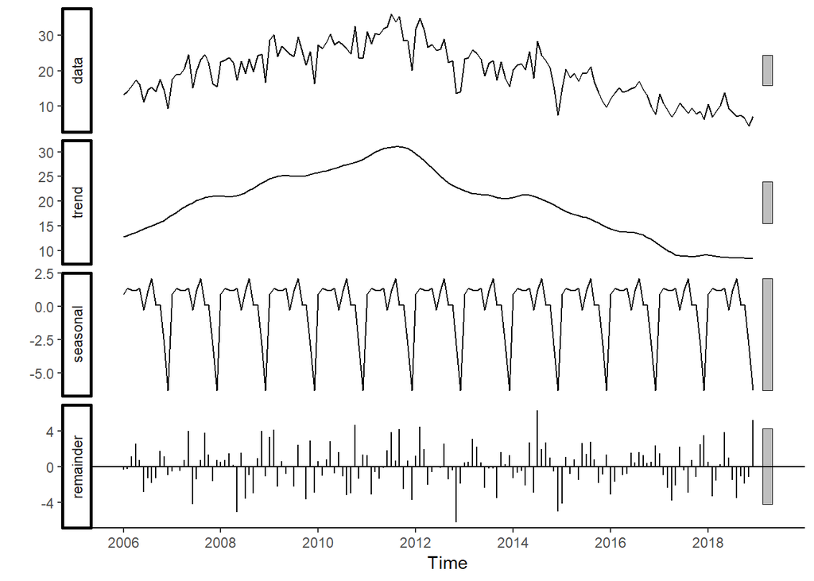

```r
# STL (Seasonality and Trend Decomposition using Loess)
autoplot(stl(ts.dat[,1], s.window = 'periodic'))
```

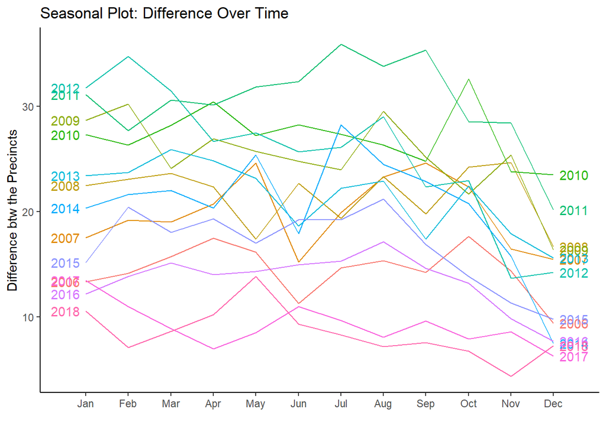

```r
# Chekcing for the seaonality
ggseasonplot(ts.dat, year.labels = TRUE, year.labels.left = TRUE) +
  ylab("Difference btw the Precincts") +
  xlab("") +
  ggtitle("Seasonal Plot: Difference Over Time") # Weak Seaonality
```

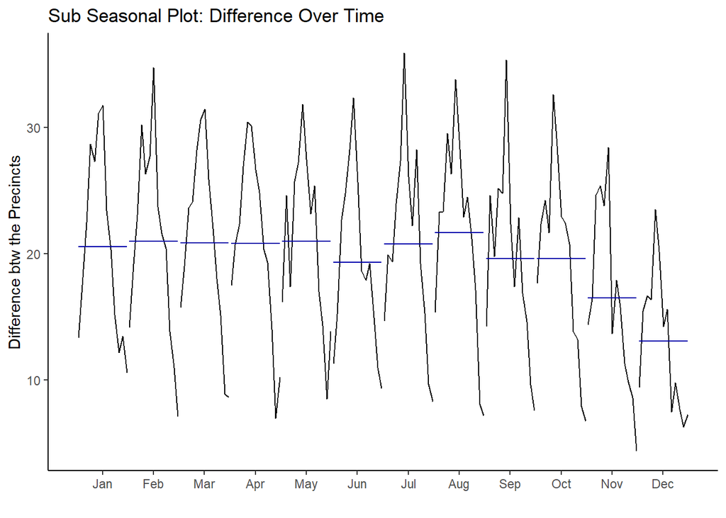

```r
# Variation by the month
ggsubseriesplot(ts.dat) +
  ylab("Difference btw the Precincts") +
  xlab("") +
  ggtitle("Sub Seasonal Plot: Difference Over Time")
```

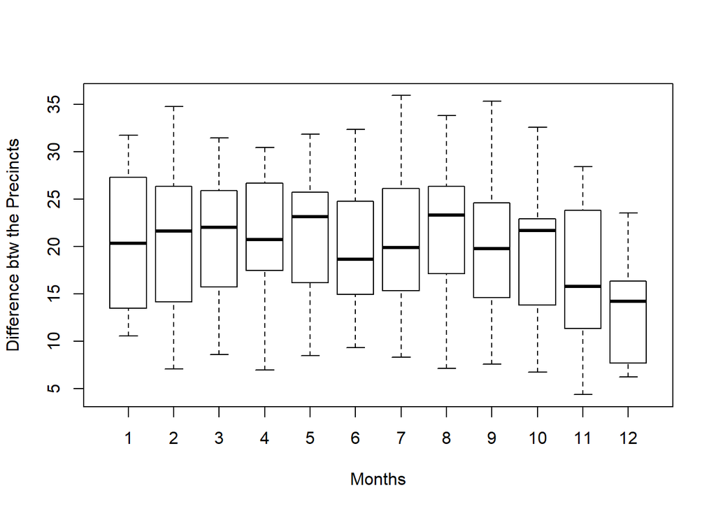

```r
boxplot(ts.dat~cycle(ts.dat), xlab = 'Months', ylab = 'Difference btw the Precincts')
```

```r
q3.dat = dat[arrest_precinct == 19 | arrest_precinct == 73, .N, by = c('yr', 'arrest_date', 'yr_mon', 'arrest_precinct')]

q3.dat[, mean := mean(N), by = yr_mon]
q3.dat$arrest_precinct = as.factor(q3.dat$arrest_precinct)

formula3 = create.formula(outcome.name = 'mean', input.names = c('yr', 'arrest_precinct'), dat = q3.dat)

lm3 = lm(formula = formula3, data = q3.dat)
summary(lm3)
```

```
Call:
lm(formula = formula3, data = q3.dat)

Residuals:
    Min      1Q  Median      3Q     Max
-7.6214 -2.8034 -0.1228  2.6316  7.1568

Coefficients:
                    Estimate Std. Error t value Pr(>|t|)
(Intercept)        1.458e+03  1.884e+01  77.424   <2e-16 ***
yr                -7.156e-01  9.362e-03 -76.443   <2e-16 ***
arrest_precinct73 -5.429e-03  7.006e-02  -0.077    0.938
---
Signif. codes:  0 '***' 0.001 '**' 0.01 '*' 0.05 '.' 0.1 ' ' 1

Residual standard error: 3.409 on 9469 degrees of freedom
Multiple R-squared:  0.3816,    Adjusted R-squared:  0.3815
F-statistic:  2922 on 2 and 9469 DF,  p-value: < 2.2e-16
```

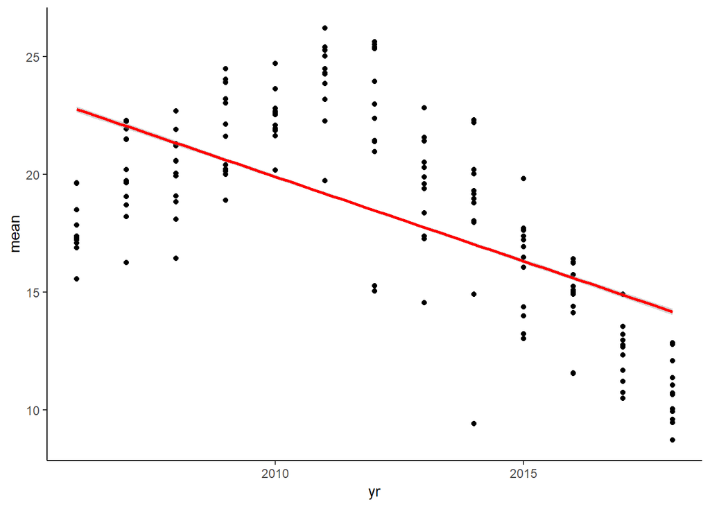

```r
ggplot(q3.dat, aes(x = yr, y = mean)) +
  geom_point() +
  stat_smooth(method = "lm", col = "red")
```

```r
rm(q3.dat)
```

## 6.4 Question 4.

```r
train = window(ts.dat, end = c(2014, 12))
test = window(ts.dat, start = c(2015, 01))
length(train)
```

```
[1] 108
```

```r
length(test)
```

```
[1] 48
```

```r
## Avg Method:
average_model = meanf(train,h = 48)
accuracy(average_model,x = ts.dat)
```

```
                        ME      RMSE       MAE         MPE      MAPE     MASE
Training set  6.894562e-16  5.851318  4.673077   -8.404388  24.20025 1.025679
Test set     -1.097932e+01 11.780223 10.979322 -119.120799 119.12080 2.409818
                  ACF1 Theil's U
Training set 0.6461398        NA
Test set     0.8193088  5.405354
```

```r
## Naive Method:
naive_model = naive(train,h=48)
accuracy(naive_model,x = ts.dat)
```

```
                      ME     RMSE      MAE       MPE     MAPE      MASE
Training set -0.05490004 4.621628 3.583446 -3.248599 17.51529 0.7865195
Test set      4.49220139 6.197420 4.763585 28.584154 33.66600 1.0455446
                   ACF1 Theil's U
Training set -0.3576170        NA
Test set      0.8193088  1.620428
```

```r
## Seasonal Naive Method:
seasonal_naive_model = snaive(train,h=48)
accuracy(seasonal_naive_model,x = ts.dat)
```

```
                     ME      RMSE      MAE         MPE     MAPE     MASE
Training set  0.7644501  5.454814 4.556080   0.8382564 20.37295 1.000000
Test set     -8.6315622 10.160929 8.790532 -89.9218680 91.29253 1.929407
                  ACF1 Theil's U
Training set 0.5145345        NA
Test set     0.4086452  4.351039
```

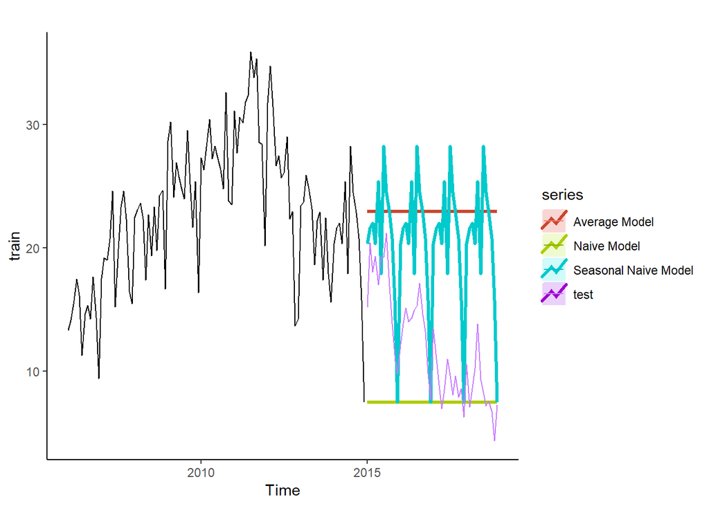

```r
## Plots 1:
autoplot(train)+
  autolayer(average_model,PI = F,size=1.1,series = 'Average Model')+
  autolayer(naive_model,PI=F,size=1.1, series='Naive Model')+
  autolayer(seasonal_naive_model,PI=F,size=1.1,series='Seasonal Naive Model')+
  autolayer(test)
```

```r
## Drift Method:
drift_model = rwf(train,h=48,drift = T)
accuracy(drift_model,x = ts.dat)
```

```
                        ME     RMSE      MAE      MPE     MAPE      MASE
Training set -1.161957e-15 4.621301 3.583959 -2.99072 17.49340 0.7866321
Test set      5.837252e+00 6.891858 5.859245 43.60097 44.10395 1.2860276
                   ACF1 Theil's U
Training set -0.3576170        NA
Test set      0.7684354  1.977951
```

```r
## Holt's Method with Damping:
holt_damped_model = holt(train,h=48,damped = T)
accuracy(holt_damped_model,x = ts.dat)
```

```
                     ME     RMSE      MAE        MPE     MAPE      MASE
Training set -0.2728191 4.083304 3.233465  -5.245902 16.64397 0.7097034
Test set     -4.3997699 6.150654 5.299161 -56.399255 61.00296 1.1630965
                  ACF1 Theil's U
Training set 0.1109748        NA
Test set     0.8211833  2.966668
```

```r
## Holt-Winter's Seasonal Method with Multiplicative:
hw_mult = hw(train,h=48,seasonal = 'multiplicative', damped=T)
accuracy(hw_mult,x = ts.dat)
```

```
                    ME     RMSE      MAE       MPE     MAPE      MASE
Training set -0.285085 2.789163 2.129451  -3.15087 10.31493 0.4673866
Test set     -5.395353 6.634401 5.715367 -62.66821 64.26902 1.2544483
                     ACF1 Theil's U
Training set -0.008352425        NA
Test set      0.805870284  3.041418
```

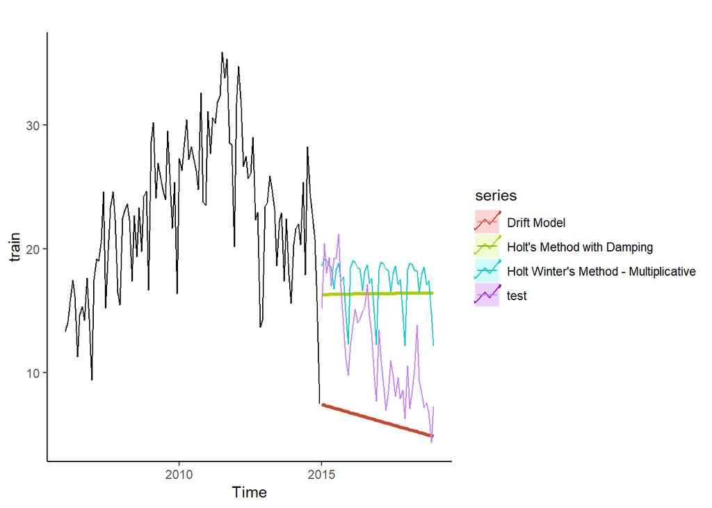

```r
## Plots 2:
autoplot(train)+
  autolayer(drift_model,PI=F,size=1.1,series='Drift Model')+
  autolayer(holt_damped_model,series="Holt's Method with Damping",PI=F,size=1.1)+
  autolayer(hw_mult,series="Holt Winter's Method - Multiplicative",PI=F)+
  autolayer(test)
```

```r
model.types = c("MAM","ANA","MNM","MAM","MMM")
ets.models = list()
ets.forecast = list()
for(i in seq(model.types)){
  ets.models[[i]] = ets(train, model =  model.types[i])
  summary(ets.models[[i]])

  ets.forecast[[i]] = forecast(ets.models[[i]],h=48)

  accuracy(ets.forecast[[i]],x = ts.dat)
}
```

```
ETS(M,Ad,M)

Call:
 ets(y = train, model = model.types[i])

  Smoothing parameters:
    alpha = 0.3449
    beta  = 0.0042
    gamma = 2e-04
    phi   = 0.9756

  Initial states:
    l = 12.2635
    b = 0.4778
    s = 0.6763 0.8785 1.0353 0.9867 1.0937 1.0529
           0.9501 1.0701 1.0689 1.0684 1.07 1.049

  sigma:  0.1383

     AIC     AICc      BIC
768.7839 776.4693 817.0623

Training set error measures:
                     ME     RMSE     MAE       MPE     MAPE      MASE
Training set -0.2924841 2.801256 2.15055 -2.895692 10.23482 0.4720175
                    ACF1
Training set -0.02553174
ETS(A,N,A)

Call:
 ets(y = train, model = model.types[i])

  Smoothing parameters:
    alpha = 0.4314
    gamma = 2e-04

  Initial states:
    l = 17.0538
    s = -7.7423 -3.1752 0.5966 0.0543 2.3921 0.9692
           -0.6522 1.5254 1.9558 1.7447 1.7548 0.5768
```

[output cut: 74 more lines]

```
    l = 12.6057
    b = 1.0381
    s = 0.6808 0.8731 1.0429 0.9878 1.085 1.0414
           0.9514 1.0666 1.0767 1.0723 1.0802 1.0419

  sigma:  0.1387

     AIC     AICc      BIC
769.8936 777.5790 818.1720

Training set error measures:
                     ME     RMSE      MAE       MPE     MAPE      MASE
Training set -0.3322622 2.819486 2.156706 -3.129483 10.29787 0.4733687
                     ACF1
Training set -0.007011273
```

```r
## Exponential Smoothing Methods(ETS)-xxx and auto:
ets_mmm = ets(train, model = 'MMM')
summary(ets_mmm)
```

```
ETS(M,Md,M)

Call:
 ets(y = train, model = "MMM")

  Smoothing parameters:
    alpha = 0.3269
    beta  = 0.008
    gamma = 1e-04
    phi   = 0.964

  Initial states:
    l = 12.6057
    b = 1.0381
    s = 0.6808 0.8731 1.0429 0.9878 1.085 1.0414
           0.9514 1.0666 1.0767 1.0723 1.0802 1.0419

  sigma:  0.1387

     AIC     AICc      BIC
769.8936 777.5790 818.1720

Training set error measures:
                     ME     RMSE      MAE       MPE     MAPE      MASE
Training set -0.3322622 2.819486 2.156706 -3.129483 10.29787 0.4733687
                     ACF1
Training set -0.007011273
```

```r
ets_auto = ets(train)
summary(ets_auto) # ANA
```

```
ETS(A,N,A)

Call:
 ets(y = train)

  Smoothing parameters:
    alpha = 0.4314
    gamma = 2e-04

  Initial states:
    l = 17.0538
    s = -7.7423 -3.1752 0.5966 0.0543 2.3921 0.9692
           -0.6522 1.5254 1.9558 1.7447 1.7548 0.5768

  sigma:  3.0218

     AIC     AICc      BIC
759.5404 764.7578 799.7724

Training set error measures:
                     ME     RMSE      MAE       MPE     MAPE      MASE
Training set 0.02490398 2.819152 2.203749 -1.345635 10.49735 0.4836941
                    ACF1
Training set -0.07352409
```

```r
ets_mmm_forecast = forecast(ets_mmm,h=48)
ets_auto_forecast = forecast(ets_auto,h=48)

accuracy(ets_mmm_forecast,x = ts.dat)
```

```
                     ME     RMSE      MAE        MPE     MAPE      MASE
Training set -0.3322622 2.819486 2.156706  -3.129483 10.29787 0.4733687
Test set     -4.0855237 5.386802 4.547006 -49.176390 51.50345 0.9980084
                     ACF1 Theil's U
Training set -0.007011273        NA
Test set      0.755834985  2.459622
```

```r
accuracy(ets_auto_forecast,x = ts.dat)
```

```
                      ME     RMSE      MAE        MPE     MAPE      MASE
Training set  0.02490398 2.819152 2.203749  -1.345635 10.49735 0.4836941
Test set     -6.24149318 7.470189 6.357862 -69.911045 70.49846 1.3954676
                    ACF1 Theil's U
Training set -0.07352409        NA
Test set      0.74438971  3.357134
```

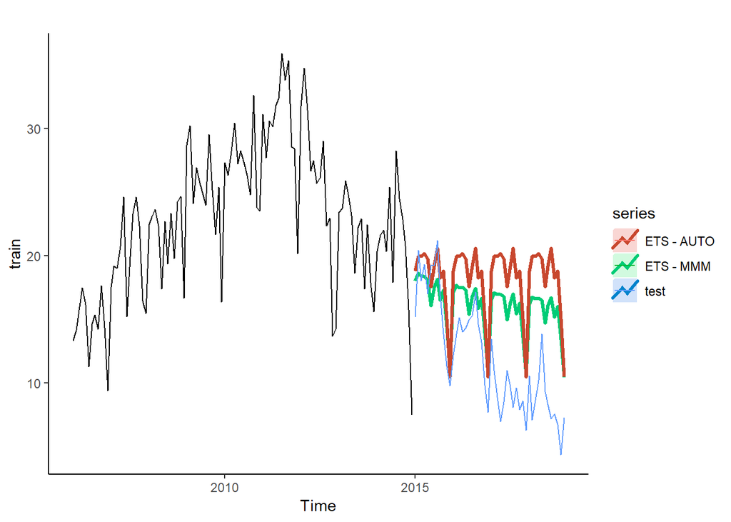

```r
## Plots 3:
autoplot(train)+
  autolayer(ets_mmm_forecast,size = 1.1, series="ETS - MMM",PI=F)+
  autolayer(ets_auto_forecast,size = 1.1, series="ETS - AUTO",PI=F)+
  autolayer(test)
```

```r
## ARIMA:

### Stablizing:
train2 = BoxCox(train,lambda = BoxCox.lambda(train))
optimal.lamda = BoxCox.lambda(train)
kpss.test(train2) # Still non-staionary
```

```
    KPSS Test for Level Stationarity

data:  train2
KPSS Level = 0.67446, Truncation lag parameter = 4, p-value = 0.01587
```

```r
### Removing Seasonality:
train2_no_seasonality = diff(x = train2,lag = 12)
kpss.test(train2_no_seasonality) # Still non-staionary
```

```
    KPSS Test for Level Stationarity

data:  train2_no_seasonality
KPSS Level = 1.2594, Truncation lag parameter = 3, p-value = 0.01
```

```r
ndiffs(train2_no_seasonality) #1
```

```
[1] 1
```

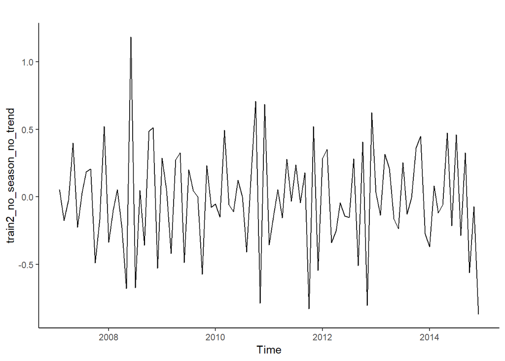

```r
### Removing Trend:
train2_no_season_no_trend = diff(train2_no_seasonality,1)
autoplot(train2_no_season_no_trend)
```

```r
kpss.test(train2_no_season_no_trend) # Now stationary!!
```

```
    KPSS Test for Level Stationarity

data:  train2_no_season_no_trend
KPSS Level = 0.061781, Truncation lag parameter = 3, p-value = 0.1
```